# DAT 301 Midterm Project I

## Midterm Project I

For midterm project you need to choose a topic that requires either a data manipulation or machine learning technique that should be equivalent in load to about 2 labs or homework assignments.

Choose a data set, define a problem (or problems) you want to solve, and do basic exploratory data analysis and apply appropriate statistical procedures to answer your questions.

You must write **ioslides** explaining which data set you used (what the resource is and what the variables are). Formulate the problem(s) and explain how you tried to answer your questions and what the conclusion is.

## Teamwork

You can form teams with your classmates. There are **2~3** members allowed for each team. Only team leader needs to submit final slides to canvas.

For submission:

- Submit both an `html` file and a `Rmd` file that you use to create the `html` file.
- The slides should clearly contain the **names** and **ASU ID** for each of your team member.

Your project will be evaluated based on whether it is a clearly reported generated by ioslides, not by the statistics or machine-learning techniques.

## Example

For example, consider a data set with human activity from UC Irvine machine learning repository. Use hierarchical clustering and/or k-means clustering to come up with a way of distinguishing between various human activities collected in the sample.

The data set can be found at http://archive.ics.uci.edu/ml/datasets/Smartphone-Based+Recognition+of+Human+Activities+and+Postural+Transitions.

The link with the video on how the data were collected can be found here: https://www.youtube.com/watch?v=XOEN9W05_4A

Consider the clustering problem.

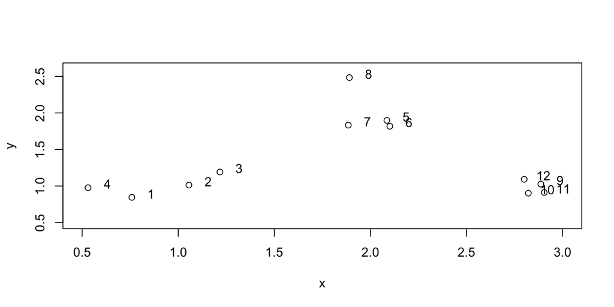

```r
set.seed(1234)
x <- rnorm(12,mean=rep(1:3,each=4),sd=0.2)
y <- rnorm(12,mean=rep(c(1,2,1),each=4),sd=0.2)
plot(x,y, xlim=c(0.5,3), ylim=c(0.5,2.6))
text(x+0.1, y+0.05, label=seq(1:12)) ## including labels (indices)
```

Now we create a data frame with `x` and `y` and make cluster with `hclust` function.

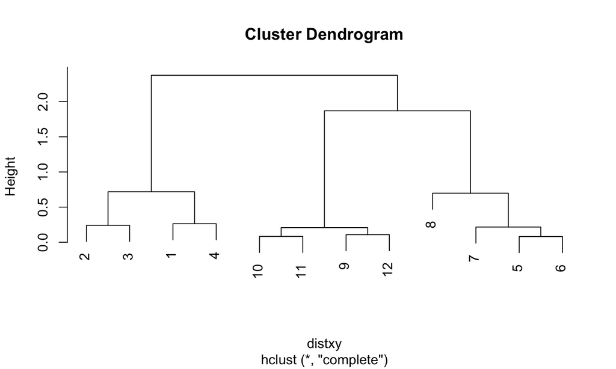

```r
 dataFrame <- data.frame(x=x,y=y)
distxy <- dist(dataFrame)
hClustering <- hclust(distxy)
plot(hClustering)
```

It would be convenient to distinguish certain clusters by colors. For that purpose we can utilize a modified version of `hclust` function, called `myplclust`, which colors the numbers according to clustering.

```r
myplclust <- function(hclust, lab = hclust$labels,
lab.col = rep(1, length(hclust$labels)), hang = 0.1, ...) {
## modifiction of plclust for plotting hclust objects *in colour*! Copyright
## Eva KF Chan 2009 Arguments: hclust: hclust object lab: a character vector
## of labels of the leaves of the tree lab.col: colour for the labels;
## NA=default device foreground colour hang: as in hclust & plclust Side
## effect: A display of hierarchical cluster with coloured leaf labels.
y <- rep(hclust$height, 2)
x <- as.numeric(hclust$merge)
y <- y[which(x < 0)]
x <- x[which(x < 0)]
x <- abs(x)
y <- y[order(x)]
x <- x[order(x)]
plot(hclust, labels = FALSE, hang = hang, ...)
text(x = x, y = y[hclust$order] - (max(hclust$height) * hang),
     labels = lab[hclust$order], col = lab.col[hclust$order], srt = 90,
     adj = c(1, 0.5), xpd = NA, ...)
}
```

Now we can re-plot the clustering dendrogram with `myplclust`.

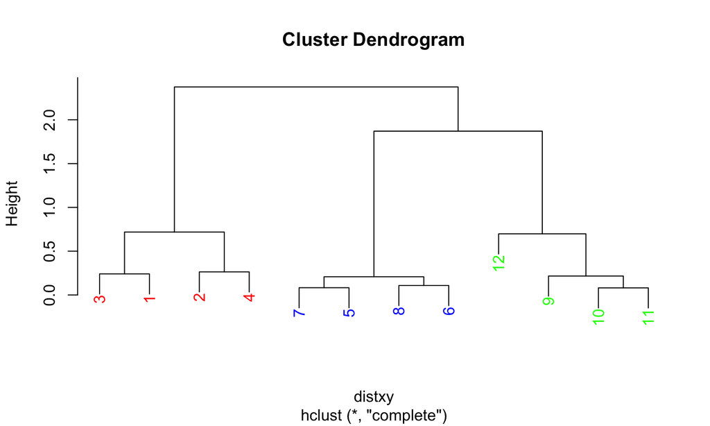

```r
myplclust(hClustering, lab = hClustering$order,
          lab.col = rep(c("red","green","blue"), each = 4))
```

Now you can explore the provided data set and try the clustering problem.

Remember, if you have questions, do NOT wait! Please to go to my office hour or post your questions to the Slack channel!

More data resources can be found [here](https://github.com/slan-teaching/DAT301/blob/master/projects/Data%20Resources%20on%20Web.pdf).